# Regression Overview

Leandro Ledesma

2024-02-07

### A simple explanation

First a recap, a correlation is a statistical analysis that showcases the strength of the relationship between two numeric variables. This is represented by the correlation coefficient which will be between -1 and 1. A regression builds on this principle by adding predictive properties (regression line) and by introducing more variables into the model to have a better understanding of which variables contribute to the variability of the outcome variable. We will be covering this one step at a time.

### A simple regression line (Mathematics)

A regression line is literally a straight line that is added to a scatterplot. The function of this line is make a prediction of what the numeric value of the outcome variable (y-axis) will be from a value of the predictor variable (x-axis). However, this created line is special because it is designed to best fit the spread of the data- meaning that this line will have the least amount of error compared to other lines that we could potentially throw on the scatterplot. Thus, this gives the regression the name of the line of best fit and is calculated from the method of least squares. As an equation, a regression will look similar to this:

$$\begin{align*}
\hat{Y} = bX + a
\end{align*}$$

Where

$\hat{Y}$: The predicted values of the outcome variable

$b$: The beta coefficient (slope)

$X$: The value of the predictor variable

$a$: The intercept of the model (What the predicted value is when X = 0)

From this equation, we need to calculate $b$ and $a$. We will already have $X$ from our data and $\hat{Y}$ will be calculated from the other three variables. The equations for calculating $b$ and $a$ are as follows:

$$\begin{align*}
a = \overline{Y} - b\overline{X}
\end{align*}$$

$$\begin{align*}
b = \frac {cov_{XY}} {s_{x}^2}
\end{align*}$$

Where

$\overline{Y}$: the mean of the values from the outcome variable

$\overline{X}$: the mean of the values from the predictor variable

$cov_{XY}$: The covariance of X and Y

$s_{X}^2$: The variance of x

### Residual Sum of Squares

It is good to become familiar with some jargon early on since it makes more complicated statistical approaches easier to understand. As mentioned above, we are specifically calculating a line that explains most of the variance of our outcome variable while at the same time reducing the error, which unexplained variance. How is this calculated or proven? Look at the scatterplot down below, the line that goes through it is the regression line, which represents the predicted values of the outcome variable $\hat{Y}$ from the values of our predictor variable $X$. The dots surrounding this line are the observed values and not all of them (actually most of them) are outside of this line. The distance then that is observed from one of our observed data points to our predicted values (from the line) is the error, which we call **residuals**. The residuals can be positive or negative, depending on whether the observed data was above or below the regression line. Next, we can take the square of all of our residuals (we will have one for each observed data) and then add them all together, this will give us our **residual sum of squares**. Lastly, we can repeat the process an infinite number of times by placing lines with difference slopes and y-intercepts on the scatterplot and then calculating their residual sum of squares. The line of best fit will always be the line that best predicts the outcome variable by explaining most of the variance, which also means reduces the error- aka the residual sum of squares. Thus, the best line will have the smallest sum of squares and that line will always be the regression line.

A quick recap: The sum of squares of the outcome variable calculated from the residuals in a regression is called the residual sum of squares and is notated as the following equation:

$$\begin{align*}
SS_{residual} = \Sigma(Y - \hat{Y})^2
\end{align*}$$

### Visualizing the data:

We will be using the same data from the ‘Correlation Overview’ page. We will simply plot a scatterplot and then add the regression line over it. We can use this line to inform us in two ways. The first is see how the predictor and outcome variable are related. By looking at the line, we can see that as we move across the x-axis the values of the y-axis are decreasing- thus these variables are negatively correlated with each other. Additionally, we can also use the line to predict values of y (Sepal Length) from values of x (Sepal Width). Now, how accurate our model ends up being is its own separate discussion.

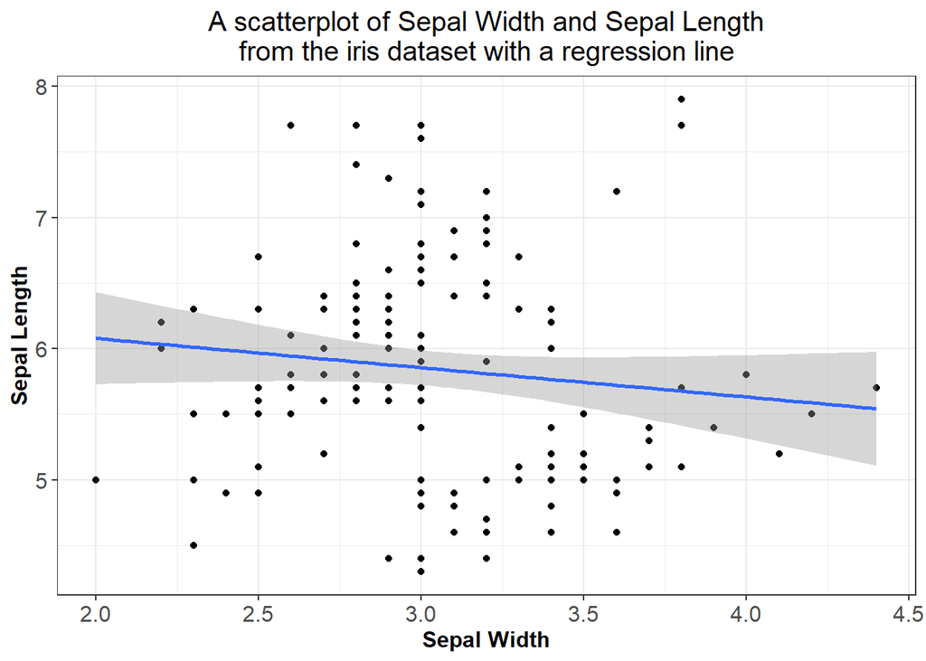

### A multiple regression line

Multiple regression builds on the logic of a simple regression by continuing to have one outcome variable or criterion ($Y$)and introducing more than one predictor variable ($X_{1},X_{2}...,X_{p}$). As recommended by David C. Howell’s Statistical Methods for Psychology textbook, we will not focus on the calculations involved in the model but what the outcomes from it mean. The equation for a multiple regression is basically identical to that of the simple regression except we have made room for more predictor variables.

$$\begin{align*}
\hat{Y} = b_{0} + b_{1}X_{1} + b_{2}X_{2} + . . . + b_{p}X_{p}
\end{align*}$$

Where

$b_{0}$: Is the y-intercept

$b_{1}, b_{2}, ..., b_{3},$: are the regression coefficients

$X_{1}, X_{2}, ..., X_{3},$: are the values of the predictor variables respectively

### Calculating a simple regression by hand

[[Click here to view script]](https://leoledesma237.github.io/LeoWebsite/Regression.Scripts/Regression.by.Hand.html)